# The line of averages

Matthew Rudd

Stat 214, Easter 2022

We’re going to start by exploring the heights of 1,078 fathers and their sons, data collected in the 1890s by the British statistician Karl Pearson and his assistants. This will give us a chance to review summary statistics, normal distributions, and tools from R’s `tidyverse` as we discuss some statistical models. To get started, load the height data, display the first 10 rows, and create histograms of  
each of the columns:

```r
library(tidyverse)
(heights <- read_csv("heights.csv", col_types = cols()))
```

```
# A tibble: 1,078 × 2
   Father   Son
    <dbl> <dbl>
 1   65.0  59.8
 2   63.3  63.2
 3   65.0  63.3
 4   65.8  62.8
 5   61.1  64.3
 6   63.0  64.2
 7   65.4  64.1
 8   64.7  64.0
 9   66.1  64.6
10   67.0  64.0
# … with 1,068 more rows
```

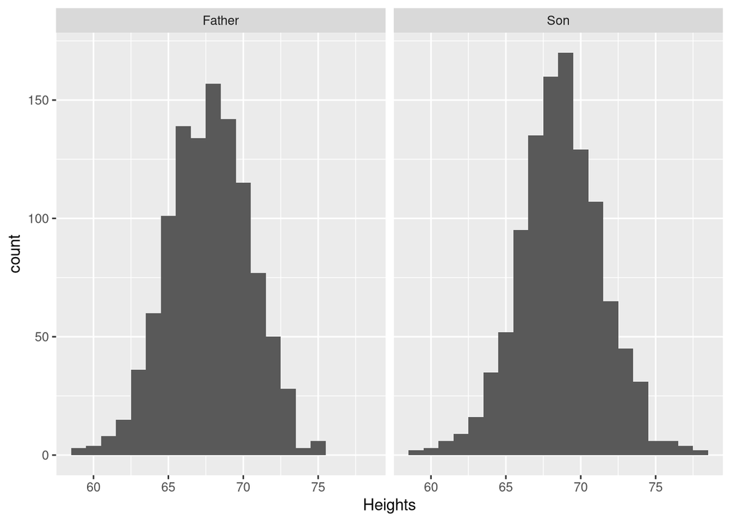

```r
ggplot(gather(heights), aes(value)) +
  geom_histogram(binwidth = 1) +
  facet_wrap( ~ key) +
  xlab("Heights")
```

We can see that both of these quantitative variables have approximately symmetric and bell-shaped distributions – in fact, each one is roughly *normally distributed*. Normally distributed variables show up all over the place in statistics, in real data and in theoretical work, so it’s important to get to know them well. A normal distribution is determined entirely by two values, its *average* and its *standard deviation*:

- the average is the center of the distribution, and
- the standard deviation determines how wide the distribution is on either side of the average.

We’ll have much more to say about standard deviations later, but for now let’s go ahead and use R’s `mean` and `sd` functions to compute these two summary statistics for the columns of the `heights` dataset:

```r
gather(heights) %>%
  group_by(key) %>%
  summarize(Average = mean(value),
            SD = sd(value))
```

```
# A tibble: 2 × 3
  key    Average    SD
  <chr>    <dbl> <dbl>
1 Father    67.7  2.74
2 Son       68.7  2.81
```

We can now describe these two columns succinctly with some concise notation: the fathers’ heights follow $N(67.687, 2.745)$, the normal distribution with average 67.687 inches and standard deviation 2.745 inches, and the sons’ heights follow $N(68.684, 2.815)$, the normal distribution with average 68.684 inches and standard deviation 2.815 inches. Look at either of the histograms above and observe that most of the heights are within 2 standard deviations of the average, and almost all of them are within 3 standard deviations of the average. As long as we’re working with a roughly normal distribution, the standard deviation tells us where most of the observations are relative to the average – it measures the *average deviation from the average*. In other words, the standard deviation measures the variability of the observations.

This is a phenomenon that delighted the Victorians as they pored over the data they collected – many biological measurements, like these heights, turn out to be roughly normally distributed. We can put this to good use and create a simple statistical model: to predict a man’s height, we can just guess 68.684 inches, the average height of the sons, and we’ll likely be correct to within 2 standard deviations, 5.6 inches or so. This is an example of a *null model*, also known as a *baseline model*, and the question is: can we come up with something better? Of course we can, that’s why we’re here!

This null model ignores the data on fathers’ heights, so we should be able to create a better predictive model by incorporating that extra information. After all, tall men tend to have tall sons and short men tend to have short sons, right? We can check this easily enough by plotting the sons’ heights against the fathers’ heights.

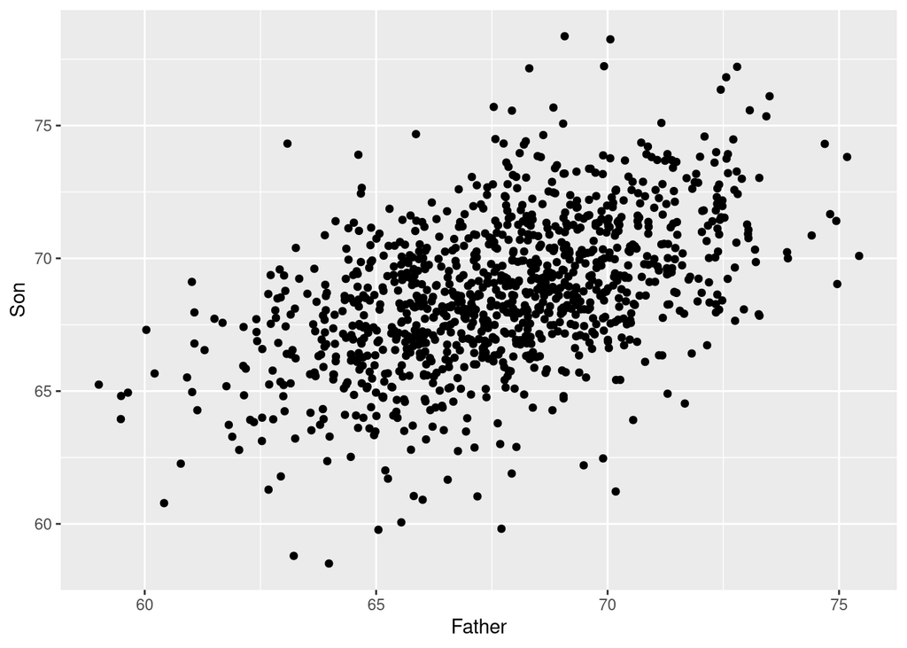

```r
(heights.plot <- ggplot(heights, aes(Father, Son)) +
   geom_point())
```

Each point in this *scatterplot* corresponds to one father and his son; the point’s horizontal position is the father’s height in inches, and the point’s vertical position is the son’s height in inches, with the axes labeled accordingly. Scatterplots are essential for presenting quantitative data like this, so we’ll use them extensively. This particular scatterplot confirms what we expected to see: shorter fathers tend to have shorter sons, while taller fathers tend to have taller sons. When the *response variable* – the one on the vertical axis – increases with the *predictor* – the variable on the horizontal axis – we say that the variables are *positively associated* or *positively correlated*; they are *negatively associated* or *negatively correlated* if the response decreases as the predictor increases. We’ll have more to say about correlation in the next section.

While the positive trend apparent in this scatterplot tells us something, *qualitative* insight has no computational power. We need to *quantify* the relationship shown so that we can do things like predict how tall a man’s son will be or describe generational variations in height numerically. With such goals in mind, let’s dig into the data! First, we’ll organize the data into groups by rounding the fathers’ heights to the nearest inch, then we’ll compute the average and the standard deviation (SD) of the heights of the sons in each group:

```r
heights <- heights %>%
  mutate(Group = round(Father))

# get summary statistics by Group
(son.means <- heights %>%
    group_by(Group) %>%
    summarize(
      N = n(),
      Mean = mean(Son),
      SD = sd(Son)
    ))
```

```
# A tibble: 17 × 4
   Group     N  Mean    SD
   <dbl> <int> <dbl> <dbl>
 1    59     3  64.7 0.662
 2    60     4  64.7 2.78
 3    61     8  65.9 2.16
 4    62    15  65.6 1.78
 5    63    36  66.5 2.91
 6    64    60  66.7 2.31
 7    65   101  67.2 2.53
 8    66   139  67.7 2.35
 9    67   134  68.1 2.24
10    68   157  69.1 2.76
11    69   142  69.4 2.30
12    70   115  69.8 2.49
13    71    77  70.5 2.31
14    72    50  70.7 2.33
15    73    28  72.0 2.76
16    74     3  70.4 0.446
17    75     6  71.7 2.05
```

To visualize the information in the table, let’s look at a couple of scatterplots that highlight certain groups: the fathers who are 64 inches tall to the nearest inch, then the fathers who are 70 inches tall to the nearest inch. In each plot, we’ve added a red point indicating the average height of the sons for that group; note that this red point does *not* belong to the original dataset.

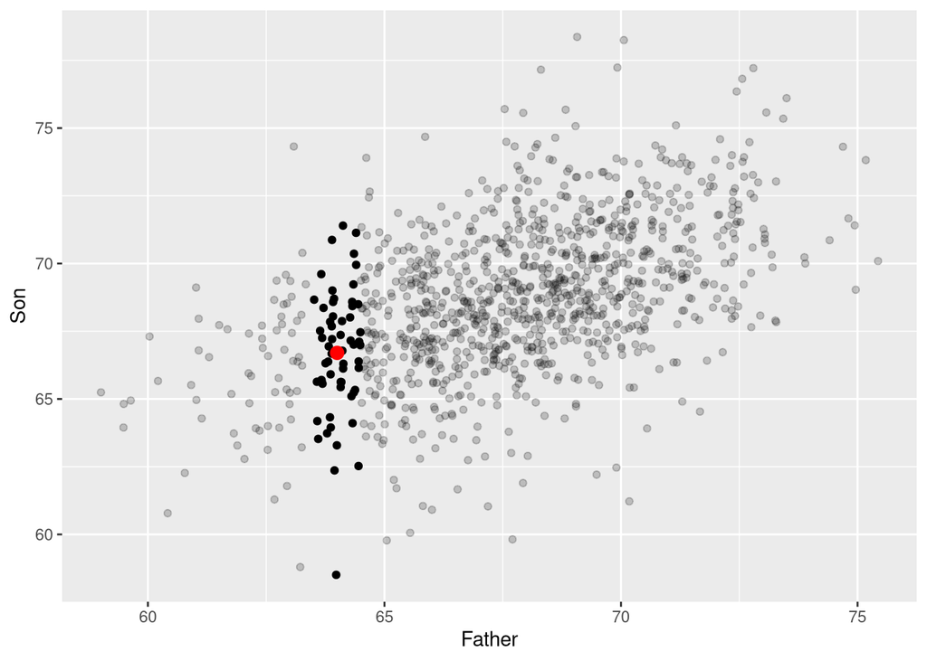

```r
ggplot() +
  geom_point(data = heights %>% filter(Group != 64),
             aes(Father, Son),
             alpha = 0.2) +
  geom_point(data = heights %>% filter(Group == 64), aes(Father, Son)) +
  geom_point(aes(x = 64, y = son.means$Mean[son.means$Group == 64]),
             color = "red",
             size = 3)
```

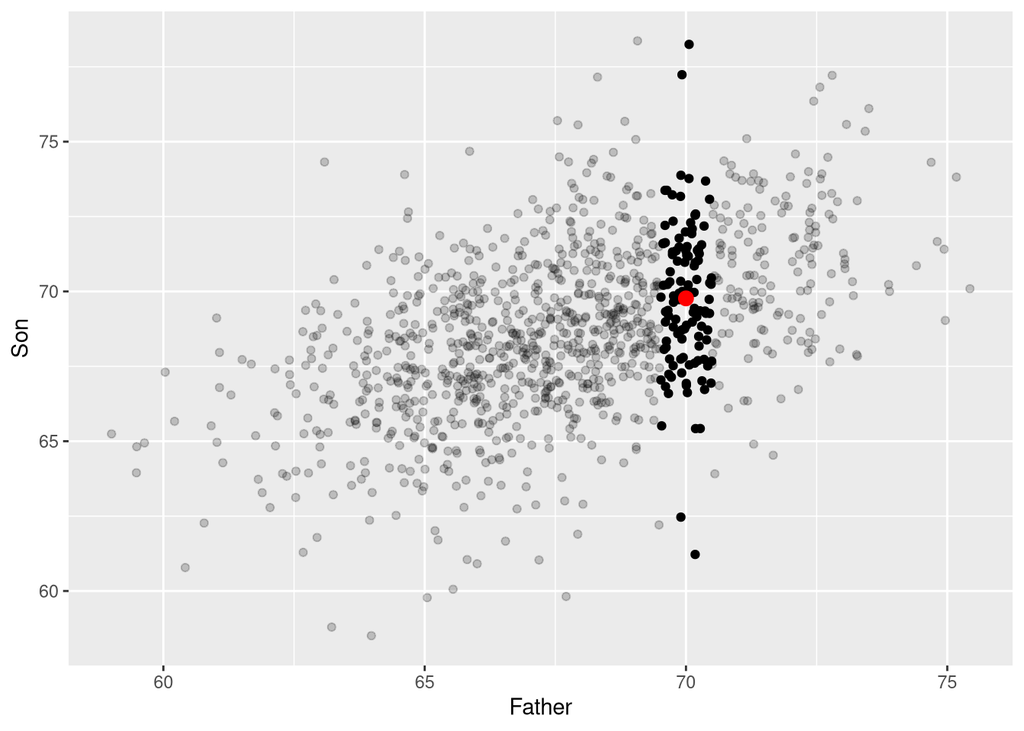

```r
ggplot() +
  geom_point(data = heights %>% filter(Group != 70),
             aes(Father, Son),
             alpha = 0.2) +
  geom_point(data = heights %>% filter(Group == 70), aes(Father, Son)) +
  geom_point(aes(x = 70, y = son.means$Mean[son.means$Group == 70]),
             color = "red",
             size = 3)
```

There are 60 father/son pairs in the first of these groups, and there are 115 father/son pairs in the second. For each of these groups, the sons’ heights remain roughly normally distributed:

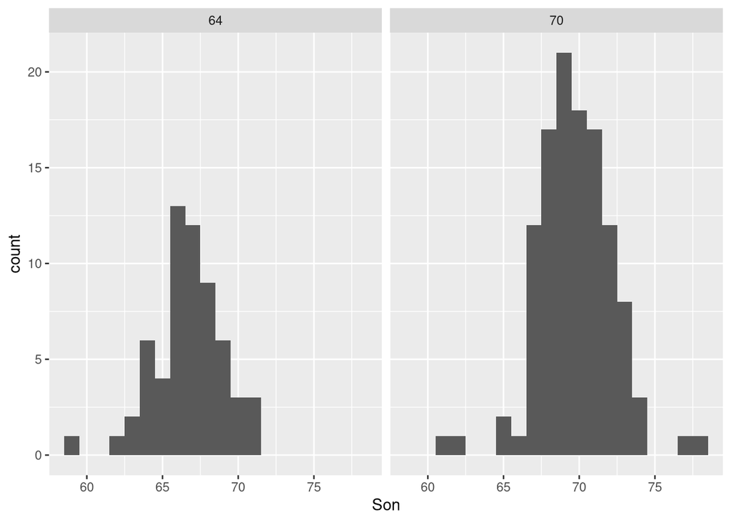

```r
ggplot(heights %>% filter(Group == 64 | Group == 70), aes(Son)) +
  geom_histogram(binwidth = 1) +
  facet_wrap(~ Group)
```

Here is what we see in these two histograms:

| Rounded height of father | Range of sons’ heights | Distribution of sons’ heights |
| --- | --- | --- |
| 64 inches | 58.5 inches to 71.4 inches | $N(66.7, 2.31)$ |
| 70 inches | 61.2 inches to 78.2 inches | $N(69.77, 2.49)$ |

As we did with the null model above, we can use these normal distributions to make predictions – better predictions, in fact, since they are better informed. If a man’s father is 64 inches tall to the nearest inch, we predict his height to be 66.7 inches; this prediction is unlikely to be off by more than 4.6 inches or so. On the other hand, if a man’s father is 70 inches tall to the nearest inch, we predict his height to be 69.77 inches; this prediction is unlikely to be off by more than 4.98 inches or so. These predictions are better than those of the null model in two important ways:

- the *point estimate* – the single best guess for the son’s height – is more accurate for each group, and
- the *margin of error* is now smaller for each prediction, since the groups have smaller standard deviations than all of the sons considered together.

Getting improved predictions is great, but doing it this way is awfully tedious. Fortunately, we are close to a much more streamlined method for making better predictions, for any father’s height, so let’s keep going, adding a red point at the average height of the sons for each group of fathers. Doing so reveals something absolutely remarkable: most of the red points are very close to being on the same line! This is the *line of averages*, shown below in blue.

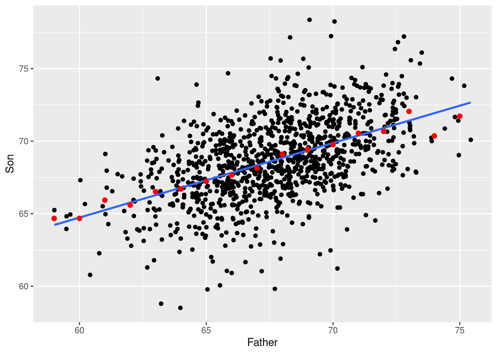

```r
heights.plot +
  geom_smooth(method = "lm", level = 0) +
  geom_point(data = son.means,
             aes(x = Group, y = Mean),
             color = "red",
             size = 2)
```

We see, using the heights of real people, how the average of a response variable can depend linearly on the predictor; when this happens, we say that there is a *linear relationship* or a *linear association* between the variables. It turns out, as explained in the next section, that the equation of this particular line of averages is

$$\text{Average height of sons} = 33.887 + .514*\text{Father's height} \ .$$

We can use this equation directly to estimate the average height of a group of sons, given the height of the father, and we can use these estimates to make our predictions. For example, if we meet a man who is 64 inches tall and want to predict his son’s height, we just compute:

$$\text{Predicted height of son} = 33.887 + .514 * 64 = 66.783 \ \text{inches} .$$

Our best guess for his son’s height is therefore the average, based on the observations available, of the heights of all of the sons whose fathers are 64 inches tall. Since the line of averages synthesizes all of the data, this predicted height differs slightly from the observed average of 66.7 given in the table above. We’re no longer limited to the rounded fathers’ heights in the table, however; if a father is 70.5 inches tall, for instance, we predict his son’s height to be

$$\text{Predicted height of son} = 33.887 + .514 * 70.5 = 70.124 \ \text{inches} .$$

Now we’re getting somewhere! The line of averages is an efficient mechanism for estimation and prediction, and its slope quantifies the relationship between the heights of fathers and sons concisely. The slope of .514 tells us, for example, that

- two fathers whose heights differ by 1 inch will have sons whose heights differ, on average, by .514 inches,
- two fathers whose heights differ by 10 inches will have sons whose heights differ, on average, by 5.14 inches,
- a father who is 1 inch above average in height is likely to have a son who is about half an inch above average in height, and
- a father who is 1 inch below average in height is likely to have a son who is about half an inch below average in height.

More generally, the equation shows that fathers who are above average in height typically have sons who are also above average in height, but not by as much; fathers who are below average in height typically have sons who are also below average in height, but not by as much. When Francis Galton, Karl Pearson’s predecessor and mentor, observed this same phenomenon in an earlier set of heights data, he called it “regression to mediocrity,” thereby introducing “regression” as a statistical term; we now summarize this *regression effect* more politely as “regression to the mean.”

The equation of the line of averages is certainly easier to use than computing averages for groups of sons one at a time, but the calculations we did earlier seem superior in one respect: the standard deviations of the heights for each group quantified their variability and provided margins of error for predictions. What we have done so far therefore raises some important questions:

- How can we determine whether there is a linear relationship between two quantitative variables?
- If there is a linear association, how do we get the equation of the line of averages?
- When we compute with the line of averages, how do we quantify the uncertainty in the resulting estimates and predictions?

We’ll answer all of these questions and more in due time!